# Do Philosophy works have emotion and how are they developing

Chang Lu

Philosophy, as a scientific discipline should be objective, rational, and should not involve strong emotions. My project seeks to find out whether the sentiment in different schools and philosophers are neutral or not, and whether the sentiment of a specific school becomes neutral over time.

# Step 0: check and install packages that are needed

```r
remove(list=ls())
packages.used=c("sentimentr", "ggplot2", "dplyr","tm", "syuzhet", "RColorBrewer","wordcloud")

# check packages that need to be installed.
packages.needed=setdiff(packages.used,
                        intersect(installed.packages()[,1],
                                  packages.used))
# install additional packages
if(length(packages.needed)>0){
  install.packages(packages.needed, dependencies = TRUE)
}

# load packages
library("sentimentr")
library("ggplot2")
library("dplyr")
library("tm")
library("syuzhet")
library("RColorBrewer")
library("wordcloud")
```

Environmental settings.

```r
print(R.version)
```

```
##                _
## platform       x86_64-apple-darwin17.0
## arch           x86_64
## os             darwin17.0
## system         x86_64, darwin17.0
## status
## major          4
## minor          1.1
## year           2021
## month          08
## day            10
## svn rev        80725
## language       R
## version.string R version 4.1.1 (2021-08-10)
## nickname       Kick Things
```

# Step 1: Data processing

```r
rawdata <- read.csv("~/Desktop/22spring/GR5243 Applied DS/spring-2022-prj1-ChangLuuu/data/philosophy_data.csv")
colnames(rawdata)
```

```
##  [1] "title"                     "author"
##  [3] "school"                    "sentence_spacy"
##  [5] "sentence_str"              "original_publication_date"
##  [7] "corpus_edition_date"       "sentence_length"
##  [9] "sentence_lowered"          "tokenized_txt"
## [11] "lemmatized_str"
```

```r
unique(rawdata$author)
```

```
##  [1] "Plato"           "Aristotle"       "Locke"           "Hume"
##  [5] "Berkeley"        "Spinoza"         "Leibniz"         "Descartes"
##  [9] "Malebranche"     "Russell"         "Moore"           "Wittgenstein"
## [13] "Lewis"           "Quine"           "Popper"          "Kripke"
## [17] "Foucault"        "Derrida"         "Deleuze"         "Merleau-Ponty"
## [21] "Husserl"         "Heidegger"       "Kant"            "Fichte"
## [25] "Hegel"           "Marx"            "Lenin"           "Smith"
## [29] "Ricardo"         "Keynes"          "Epictetus"       "Marcus Aurelius"
## [33] "Nietzsche"       "Wollstonecraft"  "Beauvoir"        "Davis"
```

```r
unique(rawdata$school)
```

```
##  [1] "plato"           "aristotle"       "empiricism"      "rationalism"
##  [5] "analytic"        "continental"     "phenomenology"   "german_idealism"
##  [9] "communism"       "capitalism"      "stoicism"        "nietzsche"
## [13] "feminism"
```

# Sept 2: EDA using Sentiment Analysis

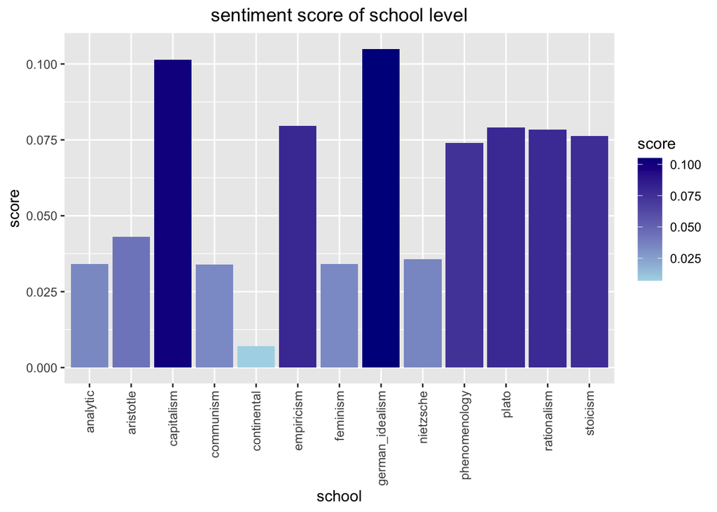

From the histogram above we can see that most schools’ sentiment scores are slightly positive, with certain school’s sentiment score approximately equal to 0, meaning this school (continental) probably has neutral sentiment.

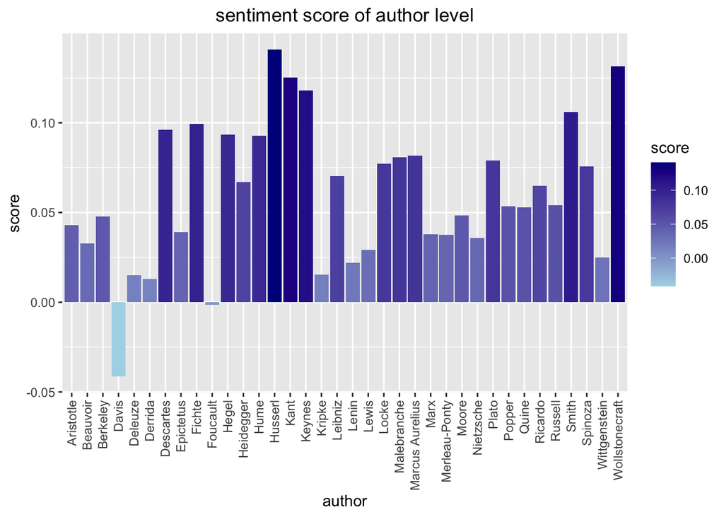

As for author level, the sentiment scores vary a lot. Some philosophers’ sentiment score are relatively greater than others. While certain philosopher’ sentiment score less than 0, meaning he has negative sentiment in his work. We can see several philosophers have sentiment score approximately equal to 0.

Next, let’s take a look at some extreme samples and some neutral samples both in school level and author level using NRC sentiment analysis.

From school level, german idealism is taken as a relative extreme positive school, and continental is taken as a neutral school.

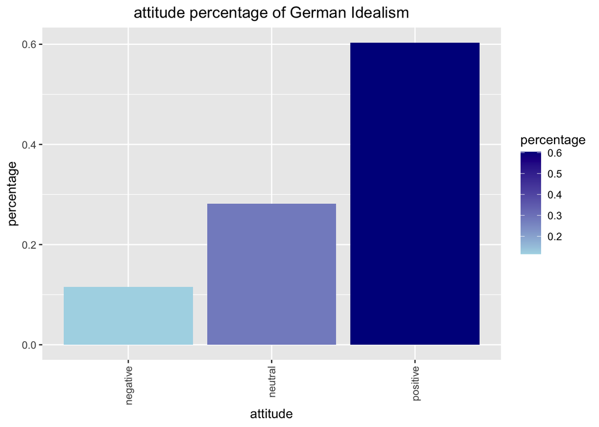

Here using NRC, we can calculate the percentage of positive and negative sentences. Sentences with equal positive and negative words are labeled as neutral.

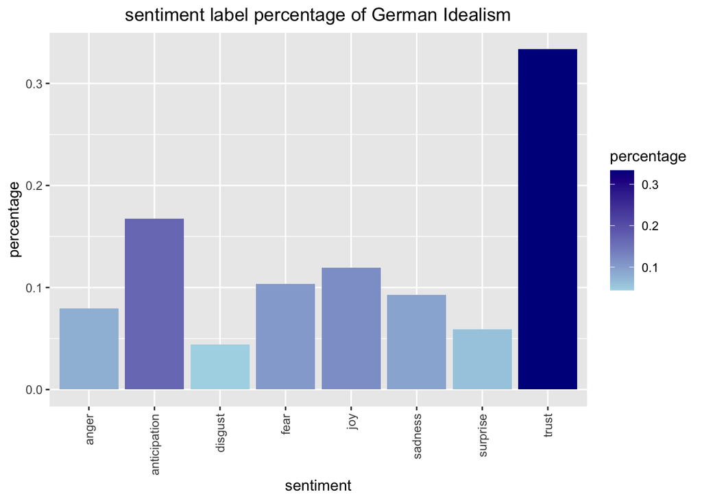

If we take a look at the sentiment labels percentage of this school, we can find out that sentences with label *trust* and *anticipation* take over half.

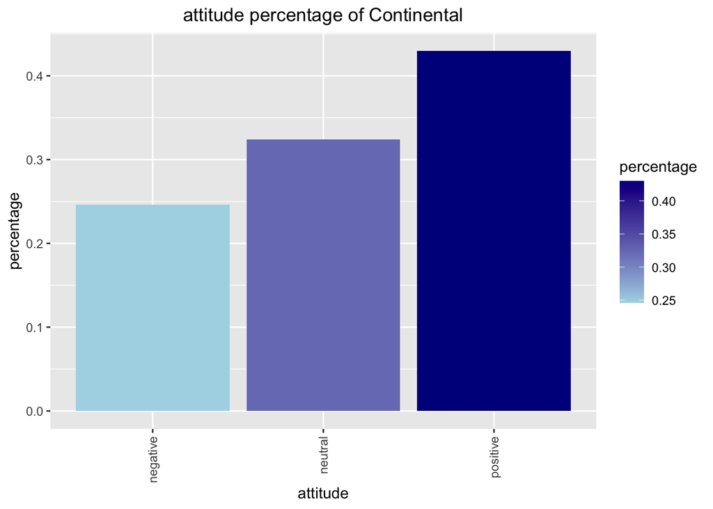

As for continental school which represent neutral school, its positive attitude is relatively lower than the former one and shows more percentage of neutral.

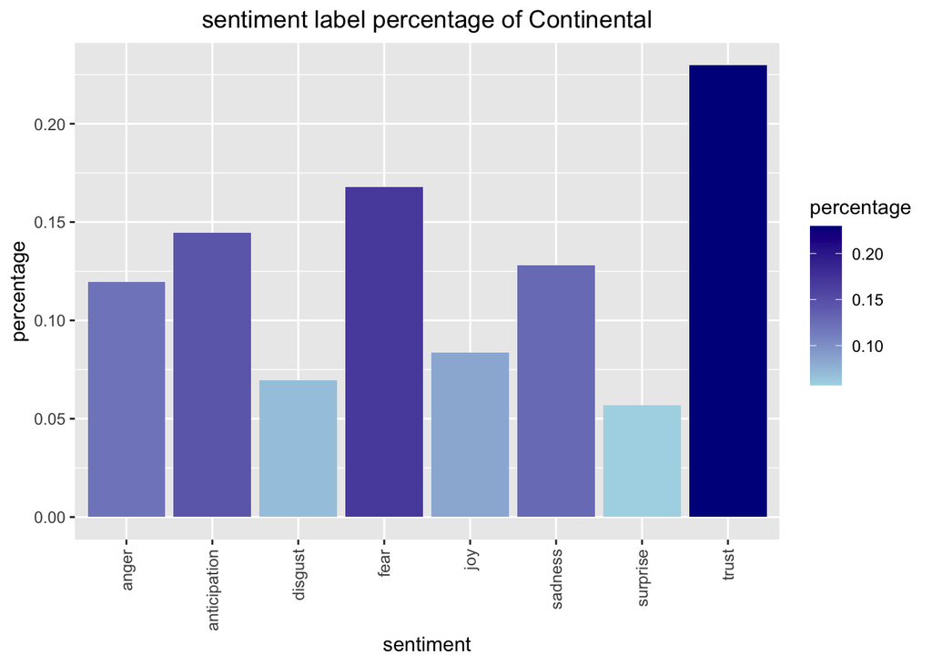

When we look at this school’s sentiment label, we can also find out that the labels are distributed relatively even compared with the positive german idealism school, which leads to the same conclusion of the histogram.

From philosopher level, Husserl is taken as an extreme positive philosopher, Davis is taken as an extreme negative philosopher, and Foucault is taken as an neutral philosopher.

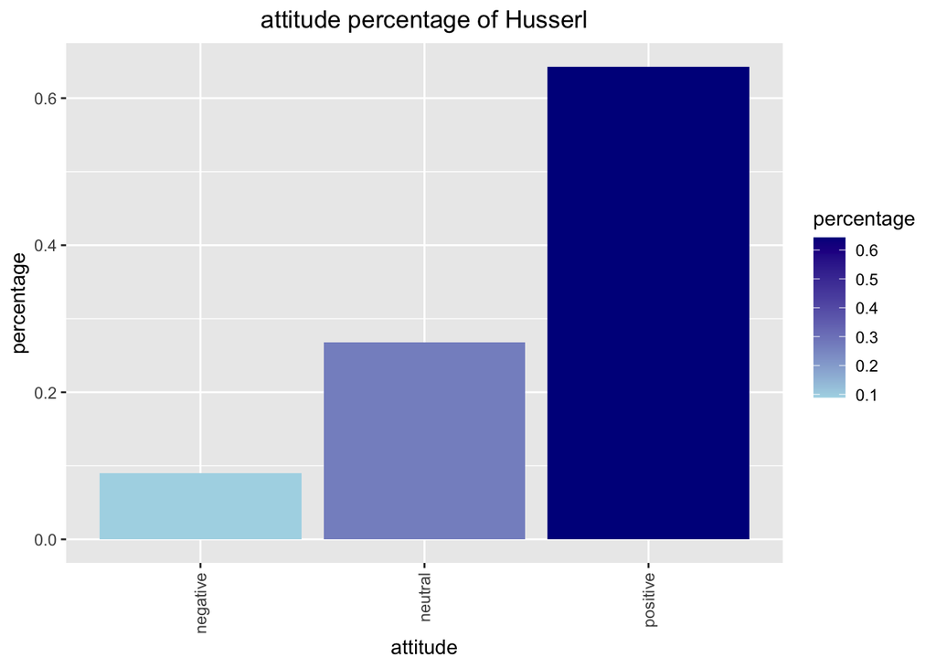

Using NRC to calculate the percentage of Husserl’s attitude, we can see that Husserl’s work contains much more positive sentences than negative and neutral ones.

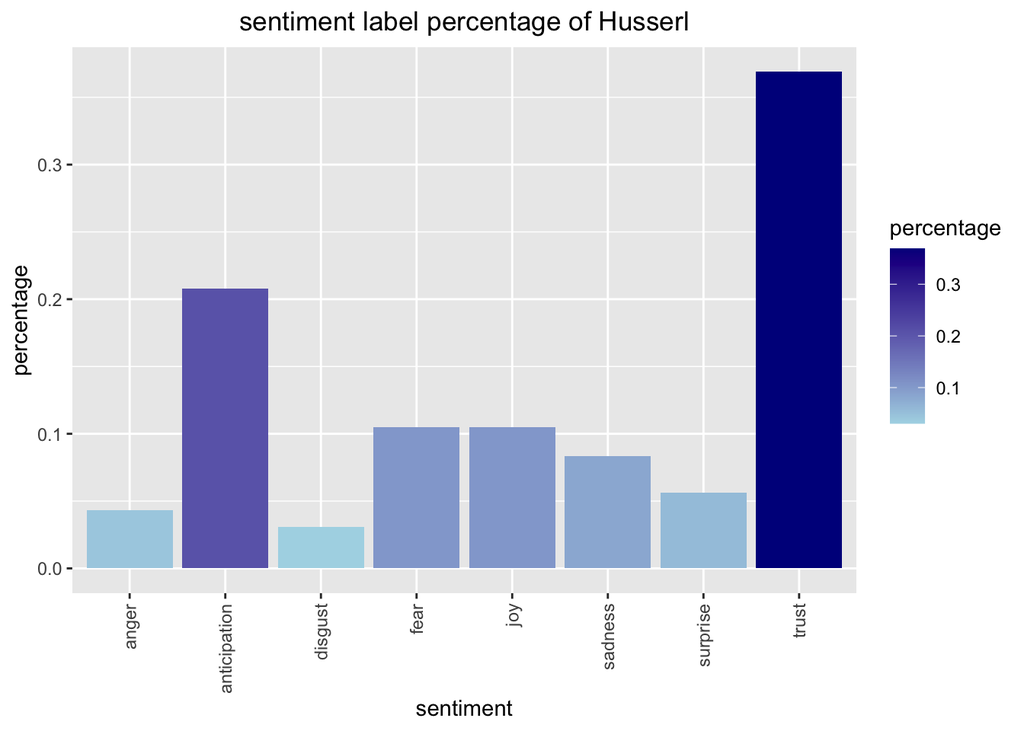

If we take a look at the sentiment labels percentage of Husserl’s work, we can find out that sentences with label *trust* and *anticipation* takes over half of his work.

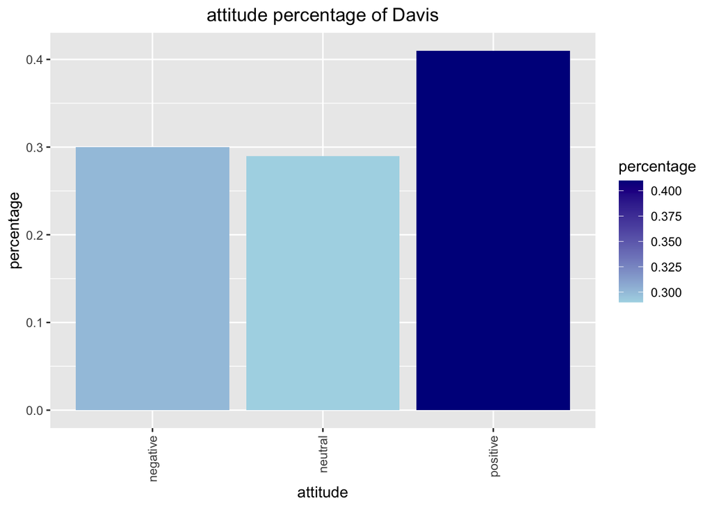

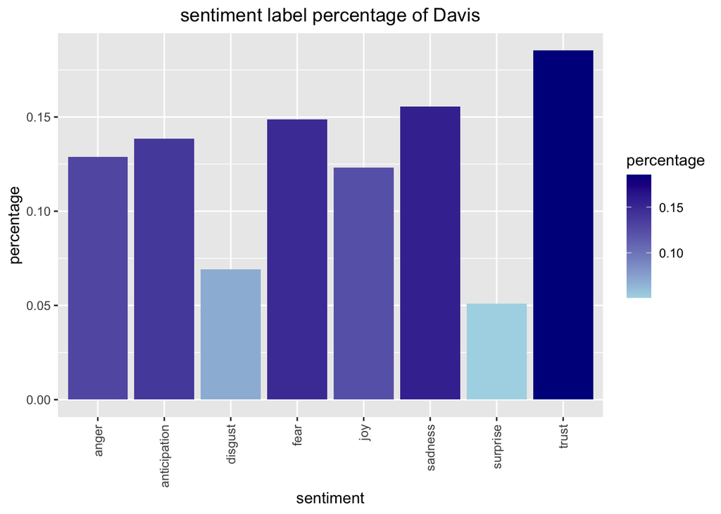

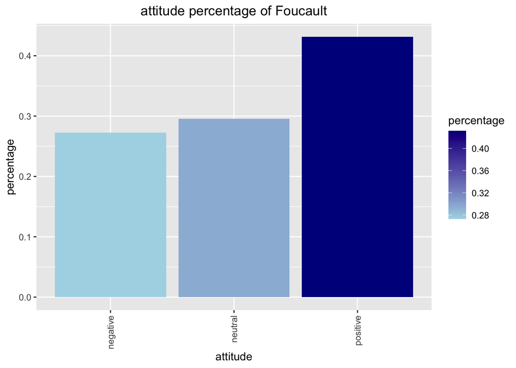

For Foucault, the distribution of his attitude is pretty much the same as in neutral school representative continental school. If we look at the school he belongs to, we can find that actually he is a continental philosopher.

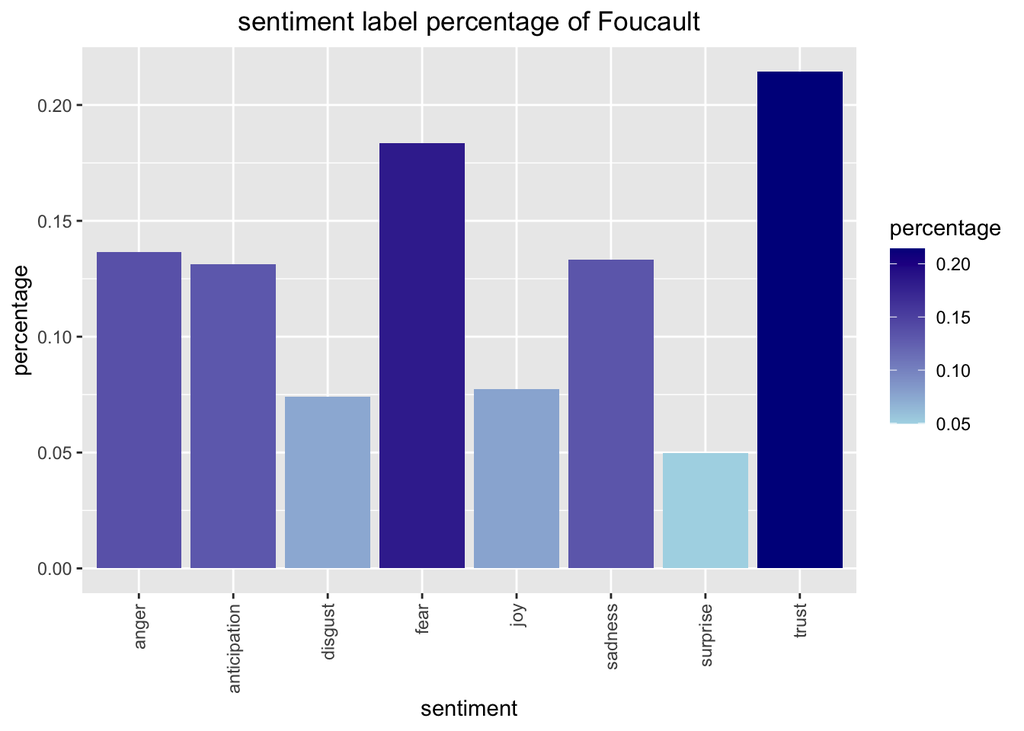

The sentence label of Foucault is also distributed more evenly.

Then we use wordcloud to have a better insight of the sentiment of their work.

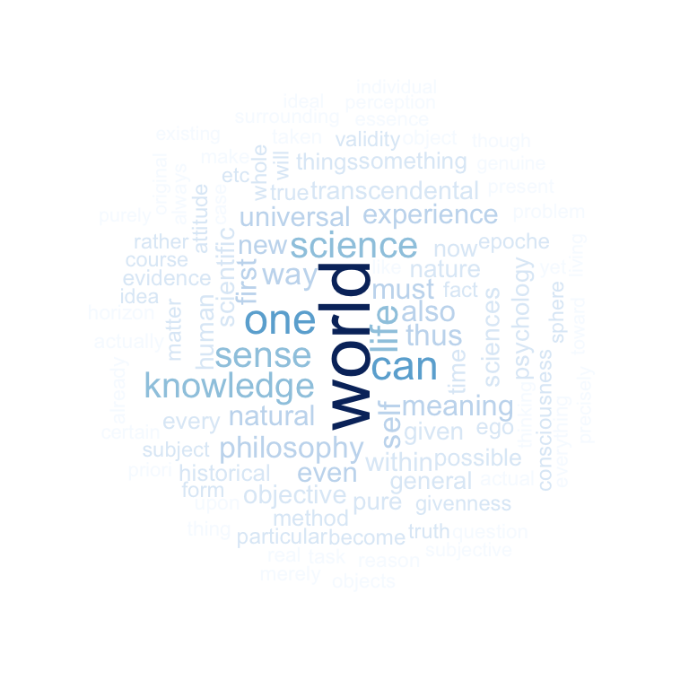

In the centre we can see words like *world*, *can*, *self*, *one* etc. These words gives one a feeling of trust and anticipation, which partly explains why Husserl’s work is relatively positive than others.

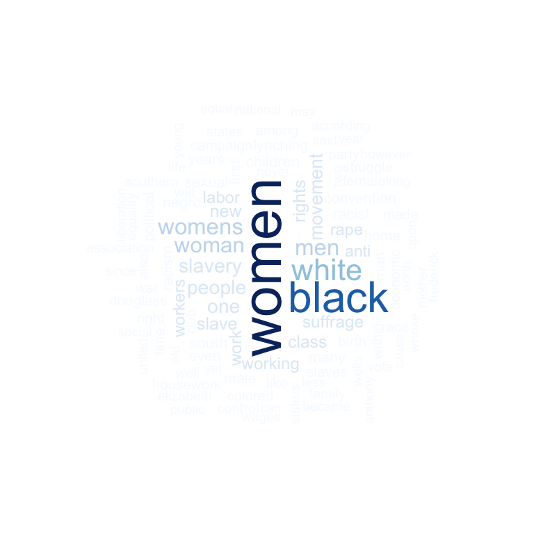

In Davis’ work, we can see words like *women*, *blace*, *white*, *slavery* etc. Maybe his work talk a lot about slavery, which makes his attitude somewhat negative.

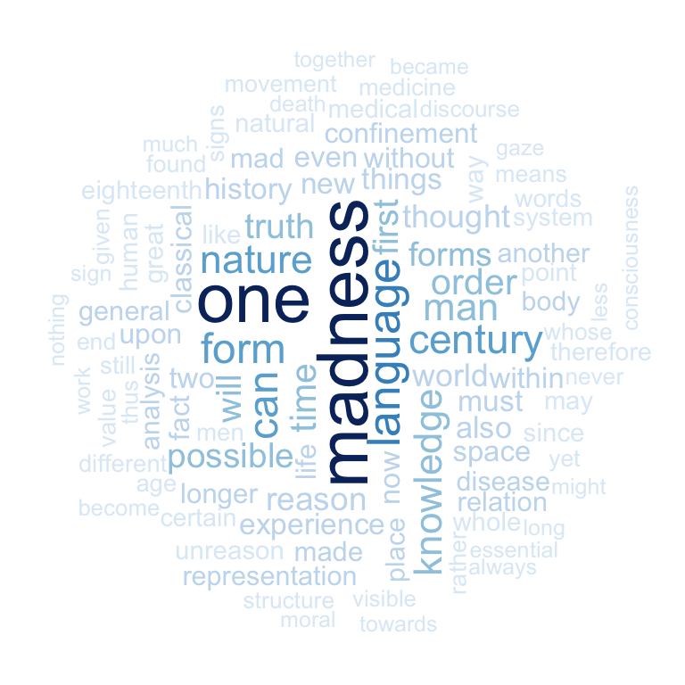

In Foucault’s work, we can see words like *madness*, *one*, *language*, *century* etc. Considering he is one of continental school, it’s not hard for us to figure out why his work is more neutral and rational.

# Step 3: Regression analysis of emotional change of certain schools over time

Next we try to find out how these schools’ sentiment develop. As we say at the beginning, philosophy should be ration and objective, which means that as schools develop, their sentiment should be more neutral. Let’s take a look at how some relatively positive schools’ sentiment develop.

From the histogram, we take some relatively positive schools, namely German Idealism, phenomenology and rationalism as examples to analyse.

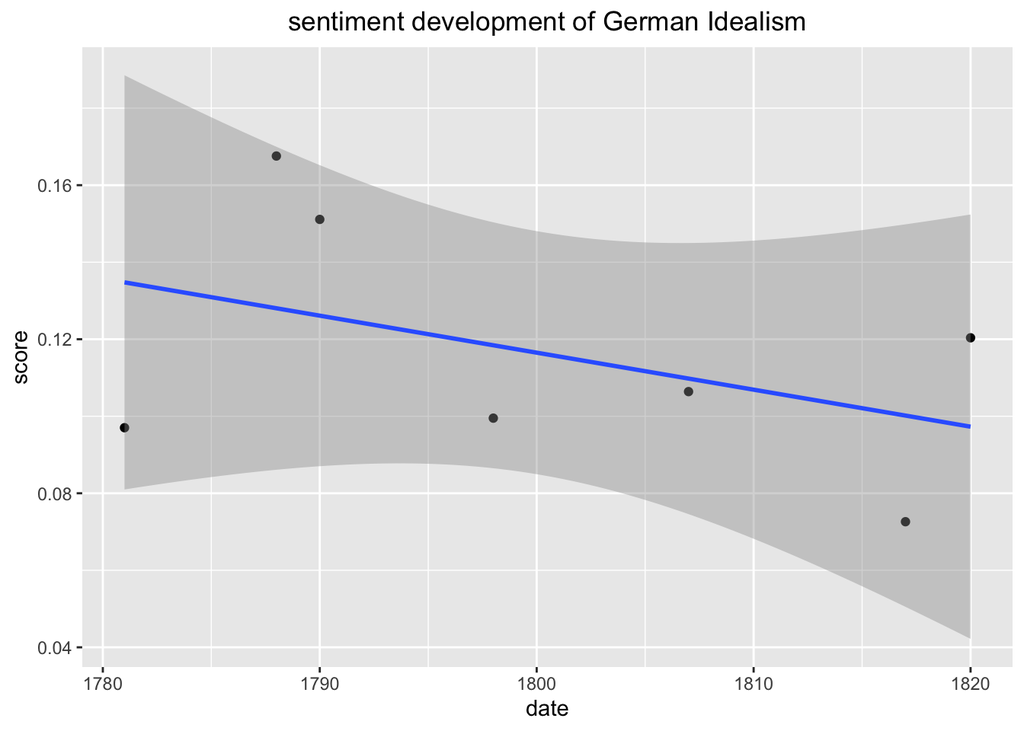

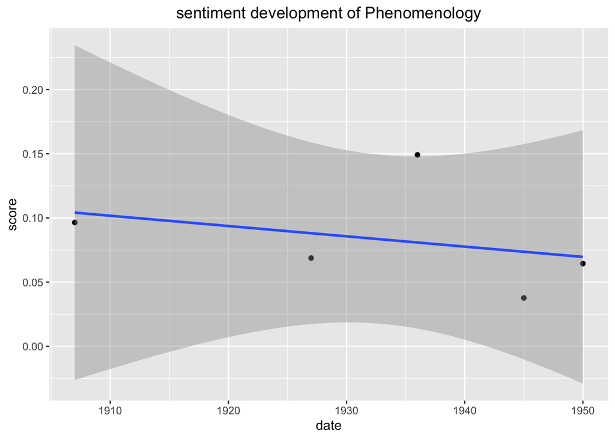

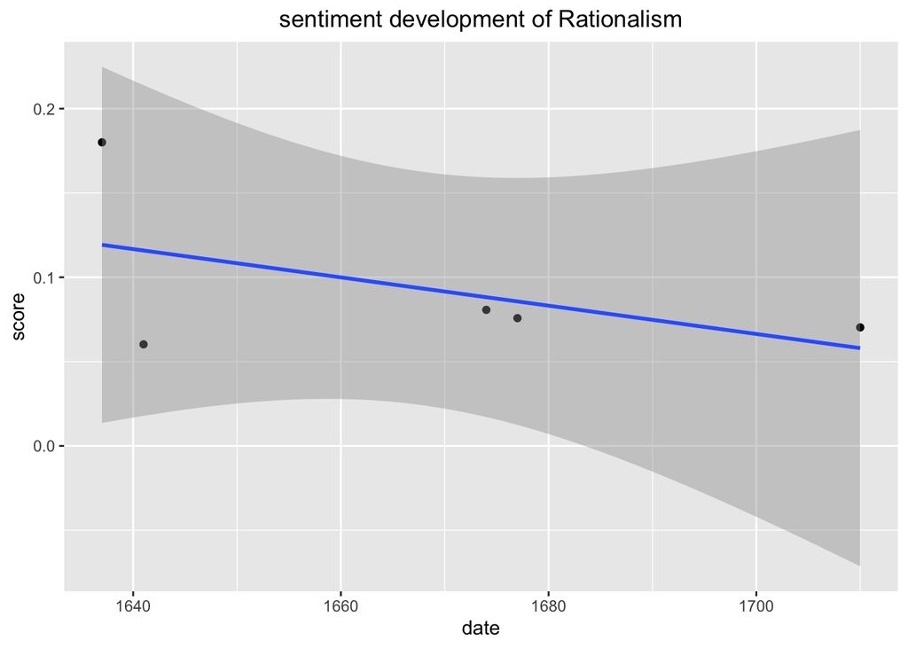

As we can see from the regression lines, all the relatively positive schools become more neutral as they develop, which makes the statement at the beginning more convincing.

# Step 4: Conclusion